# Heart Disease Prediction

Jaeseung Lee (jsl8@illinois.edu)

December 9th 2020

## Abstract

Machine learning and deep learning is actively applied in the medical/health care field. In this project, I’m going to predict the presence and absence of heart disease with the machine learning using the dataset that gives a number of variables along with a target condition. As there are many missing values, the accuracy heavily depends on variable selection and preprocessing. In the original dataset, we have 5 levels of response variable “v0”, “v1”, “v2”, “v3”,“v4”. But there are many missing values in the dataset such as “slope”, “ca”, and “thal” columns, which implies that we are not able to make elaborate prediction model, that’s why I predicted presence and absence of heart disease. As a result, types of chest pain type and presence of exercise induced angina are key feature values.

## Introduction

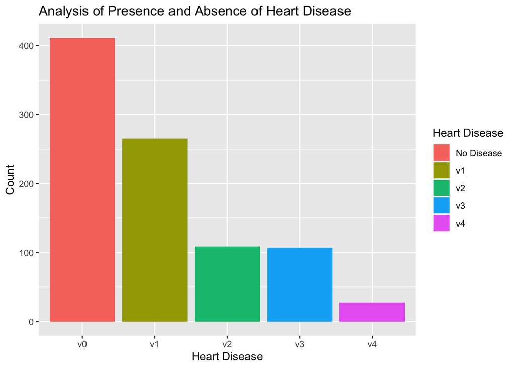

```
##
##         v0         v1         v2         v3         v4
## 0.44673913 0.28804348 0.11847826 0.11630435 0.03043478
```

## Methods

### 1. Train-Test Split

### 2. Preprocessing

Data summary

| Name | hd_trn |
| --- | --- |
| Number of rows | 738 |
| Number of columns | 15 |
| _______________________ |  |
| Column type frequency: |  |
| character | 2 |
| numeric | 13 |
| ________________________ |  |
| Group variables | None |

**Variable type: character**

| skim_variable | n_missing | complete_rate | min | max | empty | n_unique | whitespace |
| --- | --- | --- | --- | --- | --- | --- | --- |
| num | 0 | 1 | 2 | 2 | 0 | 5 | 0 |
| location | 0 | 1 | 2 | 2 | 0 | 4 | 0 |

**Variable type: numeric**

| skim_variable | n_missing | complete_rate | mean | sd | p0 | p25 | p50 | p75 | p100 | hist |
| --- | --- | --- | --- | --- | --- | --- | --- | --- | --- | --- |
| age | 0 | 1.00 | 53.62 | 9.39 | 28 | 47 | 54.0 | 60.0 | 77.0 | ▁▅▇▆▁ |
| sex | 0 | 1.00 | 0.80 | 0.40 | 0 | 1 | 1.0 | 1.0 | 1.0 | ▂▁▁▁▇ |
| cp | 0 | 1.00 | 3.27 | 0.93 | 1 | 3 | 4.0 | 4.0 | 4.0 | ▁▂▁▃▇ |
| trestbps | 48 | 0.93 | 132.08 | 18.14 | 80 | 120 | 130.0 | 140.0 | 200.0 | ▁▇▇▂▁ |
| chol | 23 | 0.97 | 198.00 | 112.77 | 0 | 171 | 223.0 | 267.5 | 603.0 | ▃▇▇▁▁ |
| fbs | 78 | 0.89 | 0.18 | 0.38 | 0 | 0 | 0.0 | 0.0 | 1.0 | ▇▁▁▁▂ |
| restecg | 2 | 1.00 | 0.60 | 0.80 | 0 | 0 | 0.0 | 1.0 | 2.0 | ▇▁▂▁▂ |
| thalach | 44 | 0.94 | 137.17 | 26.01 | 60 | 120 | 140.0 | 156.0 | 202.0 | ▁▅▇▆▂ |
| exang | 44 | 0.94 | 0.39 | 0.49 | 0 | 0 | 0.0 | 1.0 | 1.0 | ▇▁▁▁▅ |
| oldpeak | 51 | 0.93 | 0.87 | 1.06 | -2 | 0 | 0.5 | 1.5 | 6.2 | ▁▇▃▁▁ |
| slope | 242 | 0.67 | 1.77 | 0.64 | 1 | 1 | 2.0 | 2.0 | 3.0 | ▅▁▇▁▂ |
| ca | 489 | 0.34 | 0.71 | 0.97 | 0 | 0 | 0.0 | 1.0 | 3.0 | ▇▃▁▂▁ |
| thal | 390 | 0.47 | 5.08 | 1.92 | 3 | 3 | 6.0 | 7.0 | 7.0 | ▇▁▁▂▇ |

In the summary of train dataset, I have to change some variable types, numeric into categorical. To be specific fbs represent that whether condition of wheter person’s fasting blood sugar is greater than 120 mg or not, it should be factor variable.

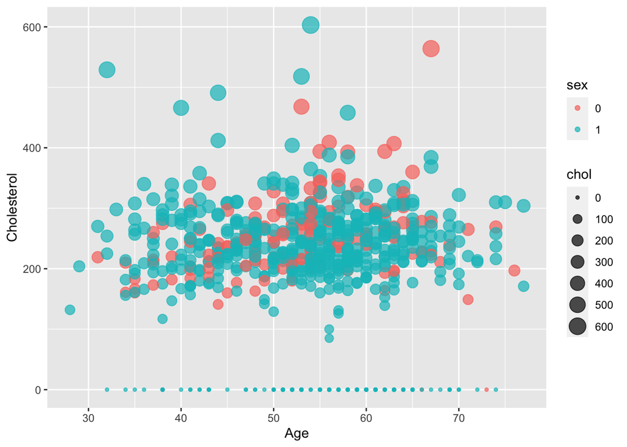

```
## [1] "0" "1"
```

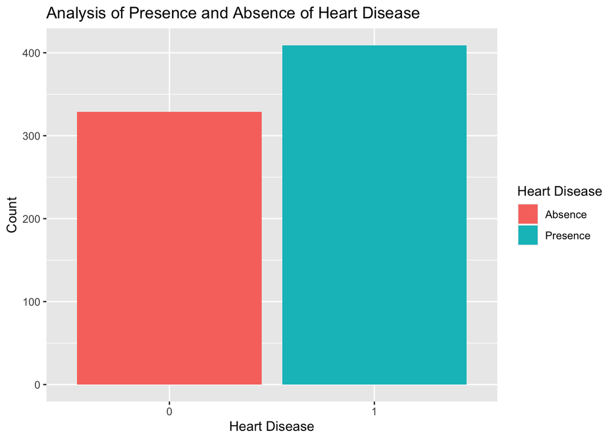

```
##
##         0         1
## 0.4457995 0.5542005
```

### 3. Feature Engineering

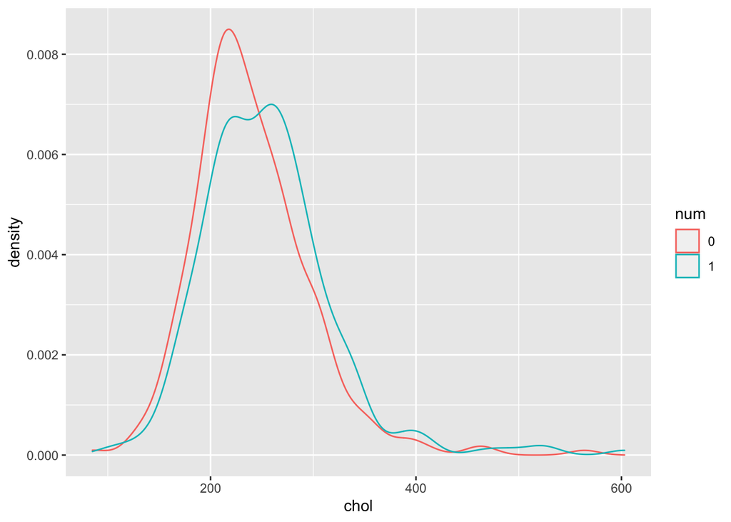

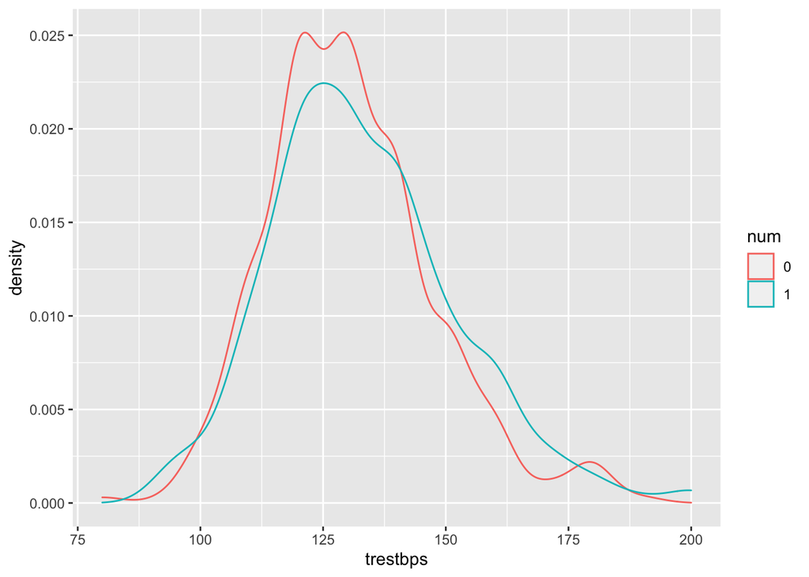

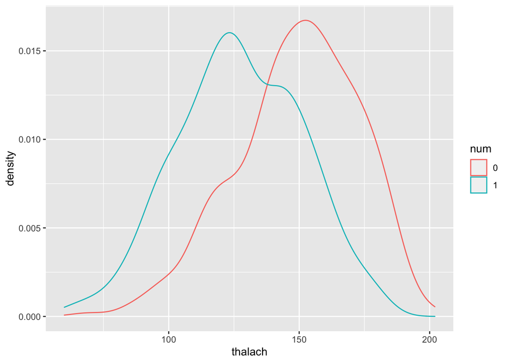

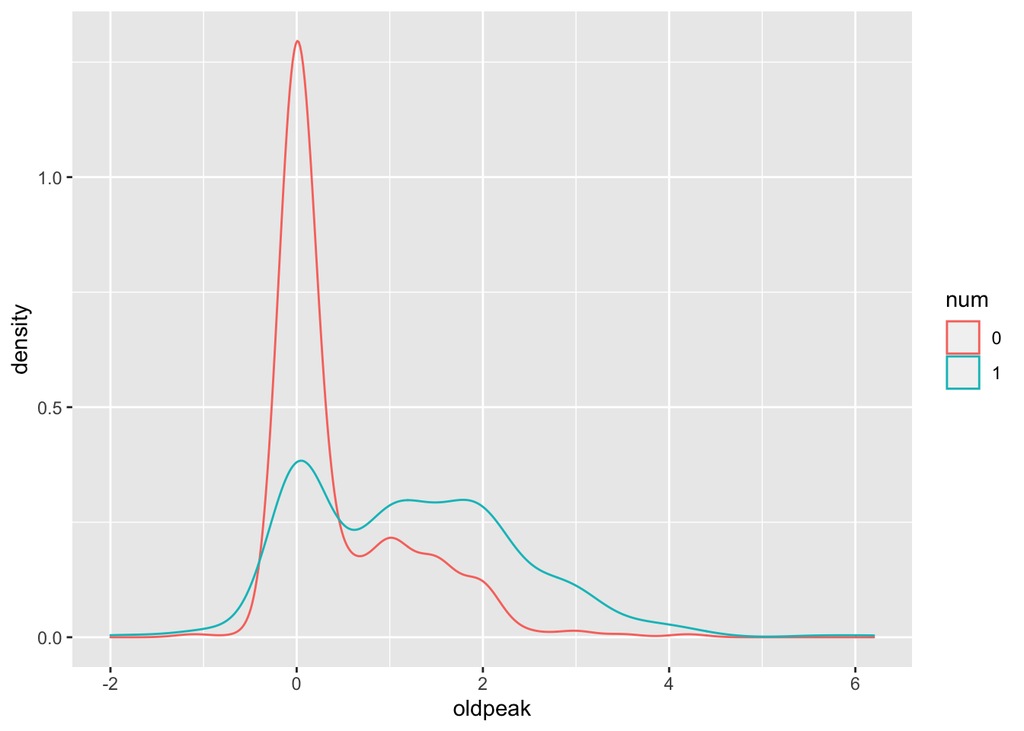

```
##
## FALSE
##   738
```

```
##
## FALSE
##   738
```

```
##
## FALSE
##   738
```

```
##
## FALSE
##   738
```

Data summary

| Name | hd_trn_full |
| --- | --- |
| Number of rows | 615 |
| Number of columns | 12 |
| _______________________ |  |
| Column type frequency: |  |
| factor | 7 |
| numeric | 5 |
| ________________________ |  |
| Group variables | None |

**Variable type: factor**

| skim_variable | n_missing | complete_rate | ordered | n_unique | top_counts |
| --- | --- | --- | --- | --- | --- |
| sex | 0 | 1 | FALSE | 2 | 1: 476, 0: 139 |
| cp | 0 | 1 | FALSE | 4 | 4: 330, 3: 132, 2: 124, 1: 29 |
| fbs | 0 | 1 | FALSE | 2 | 0: 516, 1: 99 |
| restecg | 0 | 1 | FALSE | 3 | 0: 375, 2: 138, 1: 102 |
| exang | 0 | 1 | FALSE | 2 | 0: 370, 1: 245 |
| num | 0 | 1 | FALSE | 2 | 1: 313, 0: 302 |
| location | 0 | 1 | FALSE | 4 | cl: 244, hu: 219, va: 115, ch: 37 |

**Variable type: numeric**

| skim_variable | n_missing | complete_rate | mean | sd | p0 | p25 | p50 | p75 | p100 | hist |
| --- | --- | --- | --- | --- | --- | --- | --- | --- | --- | --- |
| age | 0 | 1 | 53.21 | 9.39 | 28 | 46 | 54.00 | 60.0 | 77.0 | ▁▅▇▆▁ |
| trestbps | 0 | 1 | 132.77 | 17.46 | 92 | 120 | 130.00 | 140.0 | 200.0 | ▂▇▅▁▁ |
| chol | 0 | 1 | 246.16 | 55.47 | 85 | 213 | 247.07 | 268.5 | 603.0 | ▁▇▂▁▁ |
| thalach | 0 | 1 | 138.33 | 25.86 | 60 | 120 | 140.00 | 158.0 | 202.0 | ▁▅▇▇▂ |
| oldpeak | 0 | 1 | 0.88 | 1.05 | -1 | 0 | 0.50 | 1.5 | 6.2 | ▇▅▃▁▁ |

### 4. Training Model

```
## [1] "Decision Tree"
```

```
## Cross-Validated (5 fold) Confusion Matrix
##
## (entries are percentual average cell counts across resamples)
##
##           Reference
## Prediction    0    1
##          0 33.7 10.2
##          1 15.4 40.7
##
##  Accuracy (average) : 0.7431
```

```
## [1] "XGBoost Tree"
```

```
## Cross-Validated (5 fold) Confusion Matrix
##
## (entries are percentual average cell counts across resamples)
##
##           Reference
## Prediction    0    1
##          0 40.8  9.3
##          1  8.3 41.6
##
##  Accuracy (average) : 0.8244
```

```
## [1] "Neural Net Tree"
```

```
## Cross-Validated (5 fold) Confusion Matrix
##
## (entries are percentual average cell counts across resamples)
##
##           Reference
## Prediction    0    1
##          0 40.3 10.2
##          1  8.8 40.7
##
##  Accuracy (average) : 0.8098
```

```
## [1] "Gradient Boosting Tree"
```

```
## Cross-Validated (5 fold) Confusion Matrix
##
## (entries are percentual average cell counts across resamples)
##
##           Reference
## Prediction    0    1
##          0 39.5  8.8
##          1  9.6 42.1
##
##  Accuracy (average) : 0.8163
```

```
## [1] "Random Forest Tree"
```

```
## Cross-Validated (5 fold) Confusion Matrix
##
## (entries are percentual average cell counts across resamples)
##
##           Reference
## Prediction    0    1
##          0 38.5 10.6
##          1 10.6 40.3
##
##  Accuracy (average) : 0.7886
```

```
## [1] 30
```

```
## [1] 0.796748
```

```
##    cp_vals minsplit       acc
## 1    1e-03        5 0.7154472
## 2    1e-04        5 0.7154472
## 3    0e+00        5 0.7154472
## 4    1e-03        6 0.7154472
## 5    1e-04        6 0.7154472
## 6    0e+00        6 0.7154472
## 7    1e-03        7 0.7235772
## 8    1e-04        7 0.7235772
## 9    0e+00        7 0.7235772
## 10   1e-03        8 0.7398374
## 11   1e-04        8 0.7398374
## 12   0e+00        8 0.7398374
## 13   1e-03        9 0.7398374
## 14   1e-04        9 0.7398374
```

[output cut: 16 more lines]

```
##          actual
## predicted  0  1
##         0 46 10
##         1 15 52
```

```
## [1] 0.796748
```

### 5. Data

In the summary of train dataset using skim, there are some variable neeed to be corrected. I changed “fbs”, “num”, “location”, “cp”, “sex”, “fbs”, “restecg”, and “exang” variable types, numeric into categorical. To be specific “fbs” represent that whether condition of whether person’s fasting blood sugar is greater than 120 mg or not, it should be factor variable.

As you see on the Age - Cholesterol plot, there are 0 values of cholesterol, I changed those value in to NA. After that replaced NA value of chol, trestbps, thalach with mean value of each data columns, and replaced missing value of oldpeak with median value.

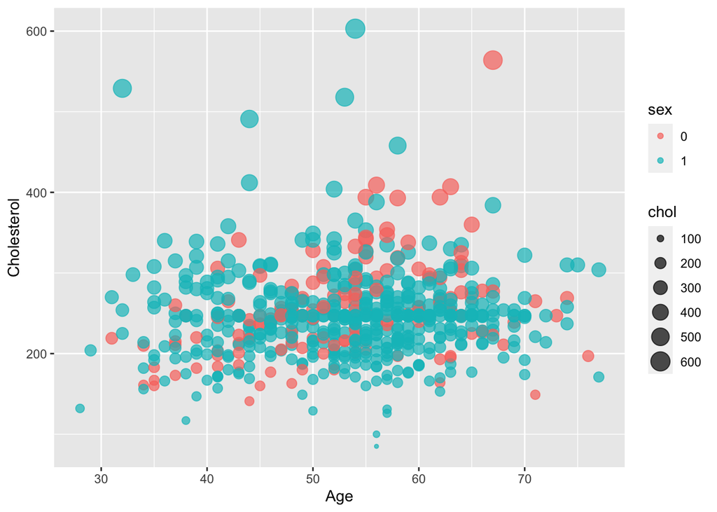

In the original dataset, we have 5 levels of response variable “v0”, “v1”, “v2”, “v3”,“v4”. But there are many missing values in the dataset such as “slope”, “ca”, and “thal” columns, which implies that we are not able to make elaborate prediction model. Therefore, I changed the level of response variable in to 1 and 0 to predict the condition whether patients have heart disease or not.

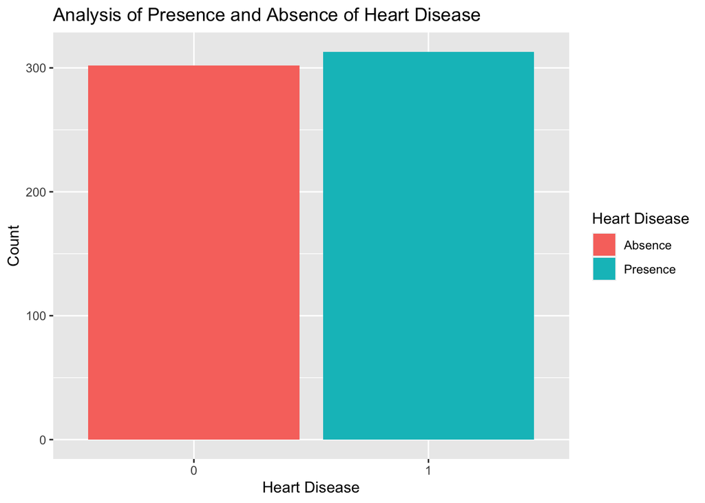

```
##
##         0         1
## 0.4910569 0.5089431
```

Lastly, I removed columns with more than 30% NAs and rows with NA.

## Results

```
## [1] "0" "1"
```

```
## [1] 182
```

Data summary

| Name | hd_tst_full_nona |
| --- | --- |
| Number of rows | 153 |
| Number of columns | 12 |
| _______________________ |  |
| Column type frequency: |  |
| factor | 7 |
| numeric | 5 |
| ________________________ |  |
| Group variables | None |

**Variable type: factor**

| skim_variable | n_missing | complete_rate | ordered | n_unique | top_counts |
| --- | --- | --- | --- | --- | --- |
| sex | 0 | 1 | FALSE | 2 | 1: 112, 0: 41 |
| cp | 0 | 1 | FALSE | 4 | 4: 75, 3: 36, 2: 33, 1: 9 |
| fbs | 0 | 1 | FALSE | 2 | 0: 136, 1: 17 |
| restecg | 0 | 1 | FALSE | 3 | 0: 90, 2: 38, 1: 25 |
| exang | 0 | 1 | FALSE | 2 | 0: 93, 1: 60 |
| location | 0 | 1 | FALSE | 4 | hu: 60, cl: 59, va: 24, ch: 10 |
| num | 0 | 1 | FALSE | 2 | 1: 83, 0: 70 |

**Variable type: numeric**

| skim_variable | n_missing | complete_rate | mean | sd | p0 | p25 | p50 | p75 | p100 | hist |
| --- | --- | --- | --- | --- | --- | --- | --- | --- | --- | --- |
| age | 0 | 1 | 52.71 | 9.27 | 29 | 46 | 54.0 | 59.0 | 75 | ▂▆▇▇▂ |
| trestbps | 0 | 1 | 133.12 | 22.71 | 0 | 120 | 130.0 | 150.0 | 200 | ▁▁▅▇▁ |
| chol | 0 | 1 | 219.46 | 90.11 | 0 | 203 | 233.0 | 273.0 | 417 | ▂▁▇▆▁ |
| thalach | 0 | 1 | 139.78 | 25.62 | 72 | 120 | 141.0 | 162.0 | 195 | ▁▅▇▇▃ |
| oldpeak | 0 | 1 | 0.94 | 1.19 | 0 | 0 | 0.3 | 1.6 | 5 | ▇▂▁▁▁ |

```
## [1] 153
```

```
## [1] 153
```

```
## [1] 0.7777778
```

```
##          actual
## predicted  0  1
##         0 57 21
##         1 13 62
```

```
## [1] 153
```

```
## [1] 153
```

```
## [1] 0.7712418
```

```
##          actual
## predicted  0  1
##         0 57 22
##         1 13 61
```

```
## [1] 153
```

```
## [1] 0.7777778
```

```
##          actual
## predicted  0  1
##         0 60 24
##         1 10 59
```

```
## [1] 0.745098
```

```
##          actual
## predicted  0  1
##         0 57 26
##         1 13 57
```

```
## [1] 0.7777778
```

```
##          actual
## predicted  0  1
##         0 57 21
##         1 13 62
```

Caret package doesn’t allow NA values in test data, that’s why it only predict 153 obs among 182 obs. When we trained data, XGBoost has better performance than other methods, however in this step, Randomforest looks better. Compared to Caret package, rpart package allows to predict test data that has NA values. Here are the two results depenidng on exististance of NAs.

```
## [1] 0.8186813
```

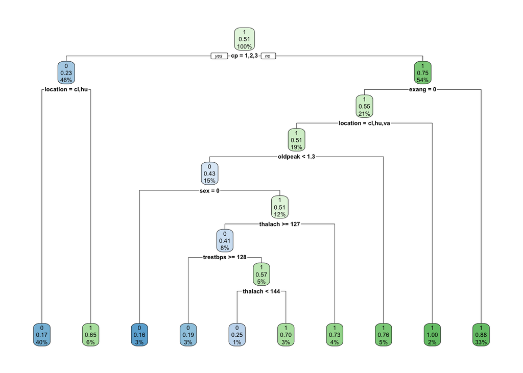

```
##          actual
## predicted  0  1
##         0 69 20
##         1 13 80
```

```
## [1] 0.8169935
```

```
##          actual
## predicted  0  1
##         0 62 20
##         1  8 63
```

## Changelog

Additionally, I used Caret package to compare more models to check false negative rate, rpart’s decision tree was better. Also, using grid search I could compare more parameters when I train the model.

## Discussion

I thought when we use complex model such as XGBoost andrandom forest which are imroved version of decision tree, those will outperform simple decision tree model. But the result wasn’t, from this experiment I realized that complicated model does not always improve the model, it depends on the dataset.

## Appendix

Here is the source of data (https://archive.ics.uci.edu/ml/datasets/Heart+Disease)